# Analysis - Car Selling Price

### Steep Price Decrease After Driving Off the Lot

It is common knowledge that once the paperwork is signed to purchase a car and the new owner drives away, thousands of dollars of value is dropped when it leave the parking lot. This principle means that even if the driver turns around with a changed mind on their minutes old purchase, they will not be able to get their full price back — by thousands of dollars.

This analysis gives answers to the question of how much value the Toyota Corolla holds at difference mileages in it’s lifetime. The data considered in the analysis ranges from cars years 1994 - 2021, and about 10 different makes. These factors are not discussed in the analysis, but it is worth noting that there is opportunity for further study beyond the purpose of this report.

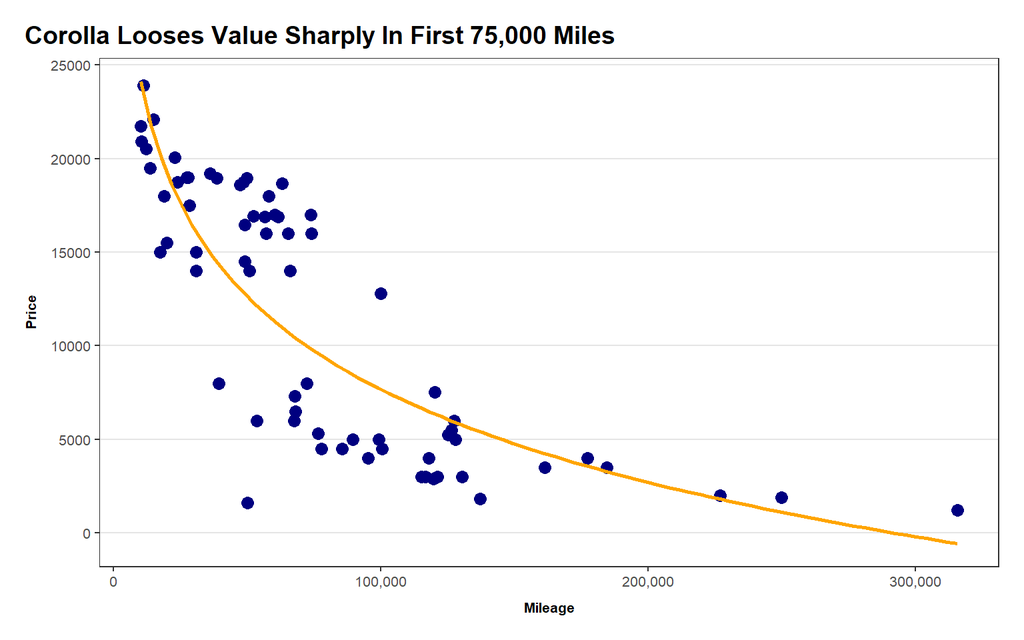

### Analysis

A simple linear regression was preformed to produce the results shown in the abstract. The explanatory variable used is car mileage and the response variable is car price. The standard model of simple linear regression was applied at first, followed by transformations in a later regression. This is the model used:

$$\underbrace{Y_i}_\text{Price} = \overbrace{\beta_0}^\text{y-int} + \overbrace{\beta_1}^\text{slope} \underbrace{X_i}_\text{Mileage} + \epsilon_i \quad \text{where} \ \epsilon_i \sim N(0, \sigma^2)$$

##### Summary of the Regression

|  | Estimate | Std. Error | t value | Pr(>\|t\|) |
| --- | --- | --- | --- | --- |
| **(Intercept)** | 9.959 | 0.09672 | 103 | 1.288e-74 |
| **Miles** | -0.00001129 | 0.0000009901 | -11.4 | 3.008e-17 |

Fitting linear model: log(Price) ~ Miles

| Observations | Residual Std. Error | $R^2$ | Adjusted $R^2$ |
| --- | --- | --- | --- |
| 68 | 0.478 | 0.6632 | 0.6581 |

The applied simple linear regression model renders as:

The hypotheses and alpha of the test are set as:

$$H_0: \beta_1 = 0$$
$$H_a: \beta_1 \neq 0$$

$$\alpha = 0.5$$
The results show that the slope is significant $(p = 3.008e-17)$. The interpretation of the slope means the car value declines 0.00001 cents with every mile driven.

#### Transformations

A simple linear regression model of car mileage as the explanatory variable and car price as the response variable renders these results:

|  | Estimate | Std. Error | t value | Pr(>\|t\|) |
| --- | --- | --- | --- | --- |
| **(Intercept)** | 18496 | 930.3 | 19.88 | 1.434e-29 |
| **Miles** | -0.09022 | 0.009523 | -9.473 | 6.321e-14 |

Fitting linear model: Price ~ Miles

| Observations | Residual Std. Error | $R^2$ | Adjusted $R^2$ |
| --- | --- | --- | --- |
| 68 | 4598 | 0.5762 | 0.5698 |

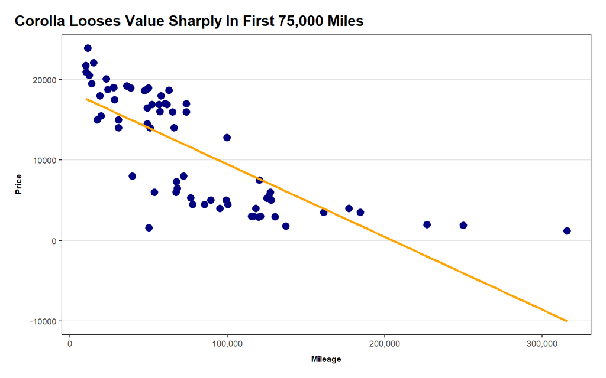

The results show strong levels of probability of these variables both show as significantly strong. Other metrics outputted give us reason to look into the fit of the regression. Most importantly, we see that the regression line does not fit the data. This means that we will have to transform the data. This handy boxcox plot will show us which is the best transformations to do:

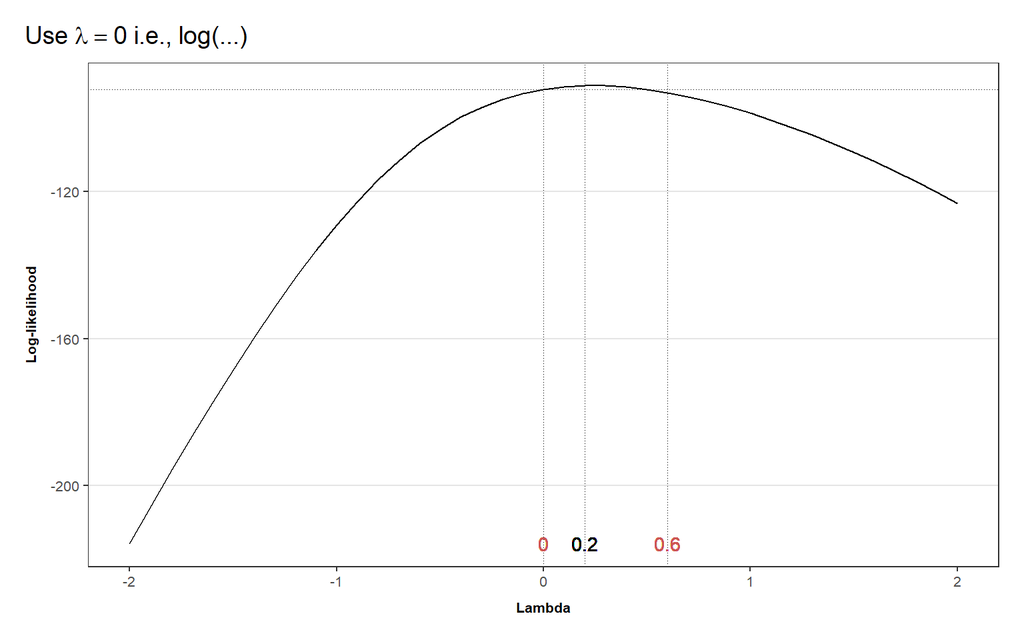

Here is the new model, summary, and graph with the logged scale applied (note that this is the same visualization shown in the abstract):

|  | Estimate | Std. Error | t value | Pr(>\|t\|) |
| --- | --- | --- | --- | --- |
| **(Intercept)** | 9.959 | 0.09672 | 103 | 1.288e-74 |
| **Miles** | -0.00001129 | 0.0000009901 | -11.4 | 3.008e-17 |

Fitting linear model: log(Price) ~ Miles

| Observations | Residual Std. Error | $R^2$ | Adjusted $R^2$ |
| --- | --- | --- | --- |
| 68 | 0.478 | 0.6632 | 0.6581 |

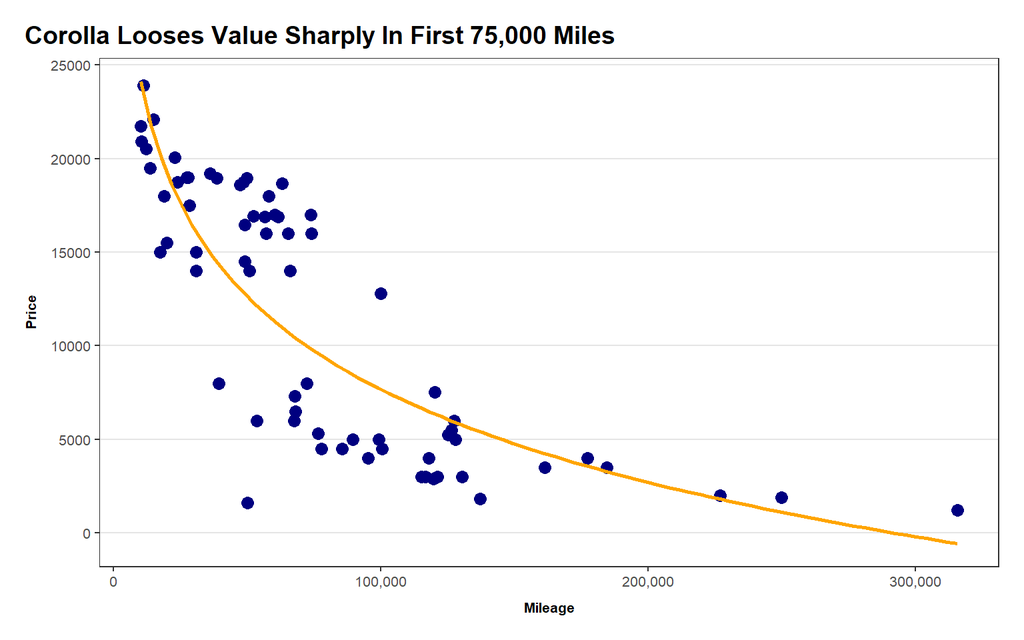

With this logged transformation applied, we see that the regression line fits the data much more accurately. This helps us have more accurate results in this simulation.

#### Our Family’s Car

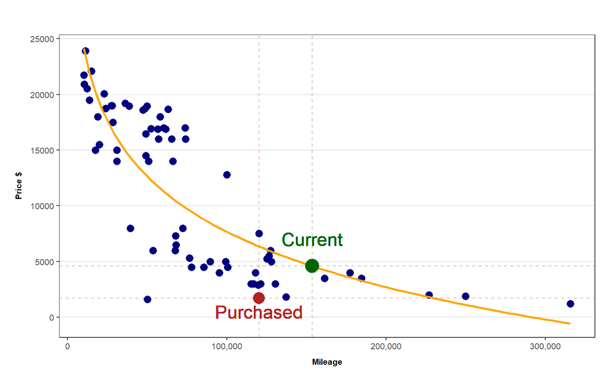

This means that we can sell our car for more than what we purchased the car. This also means (only considering these two factors of price and mileage) the car still has much more life to it.

#### Data Table

|  | Brand | Model | Year | Make | Miles | Price |
| --- | --- | --- | --- | --- | --- | --- |
| 1 | Toyota | Corolla | 1998 | CE | 121049 | 2999 |
| 2 | Toyota | Corolla | 1998 | LE | 67659 | 7300 |
| 3 | Toyota | Corolla | 1998 | CE | 119682 | 2900 |
| 4 | Toyota | Corolla | 1998 | VE | 137120 | 1800 |
| 5 | Toyota | Corolla | 2015 | S | 73961 | 15995 |
| 6 | Toyota | Corolla | 2015 | S Premium | 73771 | 16987 |
| 7 | Toyota | Corolla | 2015 | L | 52174 | 16911 |
| 8 | Toyota | Corolla | 2015 | LE | 22900 | 20065 |
| 9 | Toyota | Corolla | 2015 | LE | 50092 | 1600 |
| 10 | Toyota | Corolla | 2015 | S Plus | 56517 | 16881 |

[output cut: 58 more lines]